# stroop_effect

```python
import pandas as pd
import seaborn as sns
import matplotlib.pyplot as plt
from scipy.stats import ttest_rel
%matplotlib inline
```

## Problem 1

The independent variable is the word and color congruency (Congruent vs Incongruent). The dependent variable is the time taken to name the ink colors.

## Problem 2

The statistical test that I will perform is a two-tailed paired t-test. This test is used to compare the means of two populations when the samples from each population can be paired. A t-test is used instead of a z-test because the number of samples is less than 30, and the standard deviation of the population is not known.

The null hypothesis is that the color and word mismatch has no effect on the time taken to name the ink colors.

$H_0:$ $\mu_{congruent}=\mu_{incongruent}$

The alternative hypothesis is that the mismatch of color and word does effect the time taken to name the ink colors.

$H_A:$ $\mu_{congruent}\neq\mu_{incongruent}$

```python
df = pd.read_csv('stroopdata.csv')
```

```python
df
```

|  | Congruent | Incongruent |
| --- | --- | --- |
| 0 | 12.079 | 19.278 |
| 1 | 16.791 | 18.741 |
| 2 | 9.564 | 21.214 |
| 3 | 8.630 | 15.687 |
| 4 | 14.669 | 22.803 |
| 5 | 12.238 | 20.878 |
| 6 | 14.692 | 24.572 |
| 7 | 8.987 | 17.394 |
| 8 | 9.401 | 20.762 |
| 9 | 14.480 | 26.282 |
| 10 | 22.328 | 24.524 |
| 11 | 15.298 | 18.644 |
| 12 | 15.073 | 17.510 |
| 13 | 16.929 | 20.330 |
| 14 | 18.200 | 35.255 |
| 15 | 12.130 | 22.158 |
| 16 | 18.495 | 25.139 |
| 17 | 10.639 | 20.429 |
| 18 | 11.344 | 17.425 |
| 19 | 12.369 | 34.288 |
| 20 | 12.944 | 23.894 |
| 21 | 14.233 | 17.960 |
| 22 | 19.710 | 22.058 |
| 23 | 16.004 | 21.157 |

## Problem 3: Descriptive Statistics

```python
df.describe()
```

|  | Congruent | Incongruent |
| --- | --- | --- |
| count | 24.000000 | 24.000000 |
| mean | 14.051125 | 22.015917 |
| std | 3.559358 | 4.797057 |
| min | 8.630000 | 15.687000 |
| 25% | 11.895250 | 18.716750 |
| 50% | 14.356500 | 21.017500 |
| 75% | 16.200750 | 24.051500 |
| max | 22.328000 | 35.255000 |

## Problem 4: Visualization

```
(5, 40)
```

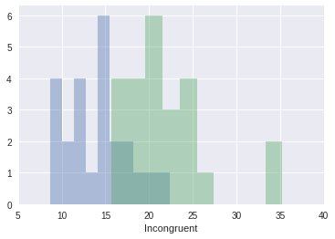

```python
fig, ax = plt.subplots()
for a in [df['Congruent'], df['Incongruent']]:
    sns.distplot(a, ax=ax, bins=10,kde=False)
ax.set_xlim([5, 40])
```

The blue histogram shows the Congruent data, and the green histogram shows the Incongruent data. These histograms shows that the means calculated in Problem 3, are about where the histograms peak, and the data is approximately normally distributed.

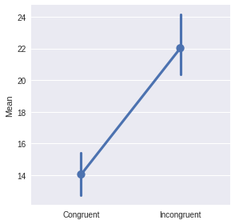

```python
g = sns.factorplot(data=df)
g.set_axis_labels("", "Mean")
```

## Problem 5

```python
ttest_rel(df['Congruent'], df['Incongruent'])
```

```
Ttest_relResult(statistic=-8.020706944109957, pvalue=4.1030005857111781e-08)
```

Let's have a confidence level of 99%. The t-statistic is -8.0207. The p-value is 4.103e-08, which is less than the threshold 1%, so we reject the null hypothesis of equal time averages for Congruent and Incongruent word/ink color at the 99% confidence level.